# An Introduction to *fakemake*

Andreas Dominik Cullmann

2018-07-13, 13:34:44

# Why Mock the Unix Make Utility?

There are [many](https://en.wikipedia.org/wiki/List_of_build_automation_software) [build systems](https://en.wikipedia.org/wiki/Build_automation), and more uses for build systems (see Powers et al. 2002, sec. 11.10 and 11.11).

I have been using the unix make utility when developing R packages since 2012. But sometimes I get caught on a machine where *make* is not available and where I am not entitled to install it[^1].

This is why I wrote *fakemake*: to build an R package conditionally on the modification times of (file) dependencies without having to rely on external software. **If you have any proper build system at hand: stick to it, do not use *fakemake*.**

# *withr* and *knitr*

Throughout this vignette I use **R**’s temporary directory, often by using `withr::with_dir(tempdir(), ...)`. Because this is a vignette and the codes are examples. In real life, we would skip the temporary directory stuff.

Vignettes are built using *knitr*, which itself uses `sink()`. As `sink()` is central to *fakemake* for redirecting output to files in the make chain, I have to disable some of *knitr*’s output here and there. Don’t worry, it’s just because *knitr* and *fakemake* both want to use `sink()` exclusively and it only affects vignettes built with *knitr*.

# Makelists

A makelist is the *fakemake*`s representation of a Makefile. It’s just a list of lists. Look at the minimal makelist provided by *fakemake*:

```r
str(fakemake::provide_make_list("minimal", clean_sink = TRUE))
```

```
## List of 4
##  $ :List of 3
##   ..$ target       : chr "all.Rout"
##   ..$ prerequisites: chr [1:2] "a1.Rout" "a2.Rout"
##   ..$ code         : chr "print(\"all\")"
##  $ :List of 2
##   ..$ target: chr "a2.Rout"
##   ..$ code  : chr "print(\"a2\")"
##  $ :List of 3
##   ..$ target       : chr "a1.Rout"
##   ..$ prerequisites: chr "b1.Rout"
##   ..$ code         : chr "print(\"a1\")"
##  $ :List of 2
##   ..$ target: chr "b1.Rout"
##   ..$ code  : chr "print(\"b1\")"
```

Each sublist represents a Makefile’s target rule and has several items: at least a *target* and either *code* or *prerequisites*, possibly both. This makelist would still be a Makefile’s valid representation if target rule #3 with target “a1.Rout” had no (or an empty) *code* entry.

Other possible target rule entries are:

- *alias*: An alias to target that would be easier to remember and/or type.
- *sink*: By default, all output of the *code* entry is dumped (well, with **R**’s *sink* function) into a file with the mame given by *target*. If *target* should be created by the *code* you will want to redirect the output into *sink*.
- *.PHONY*: If set to TRUE, the target is rebuilt unconditionally every time the target is hit (trying to mock GNU make’s .PHONY-extension.

# A Minimal Example

Suppose we would have a minimal makelist:

```r
ml <- fakemake::provide_make_list("minimal", clean_sink = TRUE)
```

## Building and Rebuilding

Now build the “all.Rout” *target*:

```r
withr::with_dir(tempdir(), print(fakemake::make("all.Rout", ml)))
```

```
## [1] "b1.Rout"  "a1.Rout"  "a2.Rout"  "all.Rout"
```

We can see the files created:

```r
show_file_mtime <- function(files = list.files(tempdir(), full.names = TRUE,
                                               pattern = "^.*\\.Rout")) {
    return(file.info(files)["mtime"])
}
show_file_mtime()
```

```
##                                        mtime
## /tmp/RtmpMmOcya/a1.Rout  2018-07-13 14:36:50
## /tmp/RtmpMmOcya/a2.Rout  2018-07-13 14:36:50
## /tmp/RtmpMmOcya/all.Rout 2018-07-13 14:36:50
## /tmp/RtmpMmOcya/b1.Rout  2018-07-13 14:36:50
```

If we wait for a second and rerun the build process, we get:

```r
# ensure the modification time would change if the files were recreated
Sys.sleep(1)
withr::with_dir(tempdir(), print(fakemake::make("all.Rout", ml)))
```

```r
show_file_mtime()
```

```
##                                        mtime
## /tmp/RtmpMmOcya/a1.Rout  2018-07-13 14:36:50
## /tmp/RtmpMmOcya/a2.Rout  2018-07-13 14:36:50
## /tmp/RtmpMmOcya/all.Rout 2018-07-13 14:36:50
## /tmp/RtmpMmOcya/b1.Rout  2018-07-13 14:36:50
```

Nothing changed. Good. Now, we change one file down the build chain:

```r
fakemake::touch(file.path(tempdir(), "b1.Rout"))
withr::with_dir(tempdir(), print(fakemake::make("all.Rout", ml)))
```

```
## [1] "a1.Rout"  "all.Rout"
```

```r
show_file_mtime()
```

```
##                                        mtime
## /tmp/RtmpMmOcya/a1.Rout  2018-07-13 14:36:51
## /tmp/RtmpMmOcya/a2.Rout  2018-07-13 14:36:50
## /tmp/RtmpMmOcya/all.Rout 2018-07-13 14:36:51
## /tmp/RtmpMmOcya/b1.Rout  2018-07-13 14:36:51
```

Since a1.Rout depends on b1.Rout and all.Rout depends on a1.Rout, these targets get rebuilt while a2.Rout stays untouched.

Had we touched a1.Rout, b1.Rout would not have been rebuilt:

```r
fakemake::touch(file.path(tempdir(), "a1.Rout"))
withr::with_dir(tempdir(), print(fakemake::make("all.Rout", ml)))
```

```
## [1] "all.Rout"
```

```r
show_file_mtime()
```

```
##                                        mtime
## /tmp/RtmpMmOcya/a1.Rout  2018-07-13 14:36:52
## /tmp/RtmpMmOcya/a2.Rout  2018-07-13 14:36:50
## /tmp/RtmpMmOcya/all.Rout 2018-07-13 14:36:52
## /tmp/RtmpMmOcya/b1.Rout  2018-07-13 14:36:51
```

## Forcing the Build

If you set the force option, you can force the target and all its prerequisites down the build chain to be built:

```r
withr::with_dir(tempdir(), print(fakemake::make("all.Rout", ml, force = TRUE)))
```

```
## [1] "b1.Rout"  "a1.Rout"  "a2.Rout"  "all.Rout"
```

If you want to force the target itself, but not all its prerequisites, set `recursive = FALSE`:

```r
withr::with_dir(tempdir(), print(fakemake::make("all.Rout", ml, force = TRUE,
                                                recursive = FALSE)))
```

```
## [1] "all.Rout"
```

## Using Aliases

If you find a target rule’s *target* too hard to type, you can use an alias:

```r
i <- which(sapply(ml, "[[", "target") == "all.Rout")
ml[[i]]["alias"] <- "all"
withr::with_dir(tempdir(), print(fakemake::make("all", ml, force = TRUE)))
```

```
## [1] "b1.Rout"  "a1.Rout"  "a2.Rout"  "all.Rout"
```

This is pointless here, but *target*s might be files down a directory tree like ‘log/testthat.Rout’ when building **R** packages.

## Diverting Output / Programmatically Creating a Target Rule’s Target

Target rule b1 dumps its output to b1.Rout:

```r
cat(readLines(file.path(tempdir(), "b1.Rout")), sep = "\n")
```

```
## [1] "b1"
```

Suppose it would programmatically create the target:

```r
i <- which(sapply(ml, "[[", "target") == "b1.Rout")
ml[[i]]["code"]  <- paste(ml[[i]]["code"],
                      "cat('hello, world\n', file = \"b1.Rout\")",
                      "print(\"foobar\")",
                      sep = ";")
withr::with_dir(tempdir(), print(fakemake::make("b1.Rout", ml, force = TRUE)))
```

```
## [1] "b1.Rout"
```

```r
cat(readLines(file.path(tempdir(), "b1.Rout")), sep = "\n")
```

```
## hello, wo[1] "foobar"
```

You end up with a broken target file, **so you need to add a *sink***:

```r
ml[[i]]["sink"] <- "b1.txt"
withr::with_dir(tempdir(), print(fakemake::make("b1.Rout", ml, force = TRUE)))
```

```
## [1] "b1.Rout"
```

Now you get what you wanted:

```r
cat(readLines(file.path(tempdir(), "b1.Rout")), sep = "\n")
```

```
## hello, world
```

```r
cat(readLines(file.path(tempdir(), "b1.txt")), sep = "\n")
```

```
## [1] "b1"
## [1] "foobar"
```

## No Code Targets

Rule a1 has *code*

```r
i <- which(sapply(ml, "[[", "target") == "a1.Rout")
ml[[i]]["code"]
```

```
## $code
## [1] "print(\"a1\")"
```

that prints “a1” into “a1.Rout”:

```r
cat(readLines(file.path(tempdir(), "a1.Rout")), sep = "\n")
```

```
## [1] "a1"
```

If we remove that code and its output file and rerun

```r
ml[[i]]["code"]  <- NULL
withr::with_dir(tempdir(), print(fakemake::make("a1.Rout", ml, force = TRUE)))
```

```
## [1] "b1.Rout" "a1.Rout"
```

the file is still created (note that target rule b1 down the make chain is run since we did not set `recursive = FALSE` ) but empty:

```r
file.size(file.path(tempdir(), "a1.Rout"))
```

```
## [1] 0
```

## Phony Targets

As you have seen, you can temporarily force a build. You may set a target to be .PHONY which forces it (but not its prerequisites) to be built:

```r
ml[[i]][".PHONY"]  <- TRUE
withr::with_dir(tempdir(), print(fakemake::make("a1.Rout", ml)))
```

```
## [1] "a1.Rout"
```

# Building **R** Packages Using *Fakemake*

We will now look a *fakemake*’s main purpose: building packages. First, we need to create a sample package.

## Creating the Package

First, we create a package skeleton:

```r
pkg_path <- file.path(tempdir(), "fakepack")
unlink(pkg_path, force = TRUE, recursive = TRUE)
devtools::create(pkg_path)
```

We add a minimal R code file:

```r
file.copy(system.file("templates", "throw.R", package = "fakemake"),
          file.path(pkg_path, "R"))
```

```
## [1] TRUE
```

This package does not make any sense. It is just a minimal working example (in the sense that it passes `R CMD build` and a simple `R CMD check`). It does not provide any functionality apart from a single internal function that is not exported via the package’s NAMESPACE. It is just there to exemplify the usage of *fakemake*.

## Setting Up the Makelist

Then we get a package makelist from *fakemake*:

```r
ml <- fakemake::provide_make_list("standard")
```

This list is a bit more complex than the minimal example above, so we visualize it:

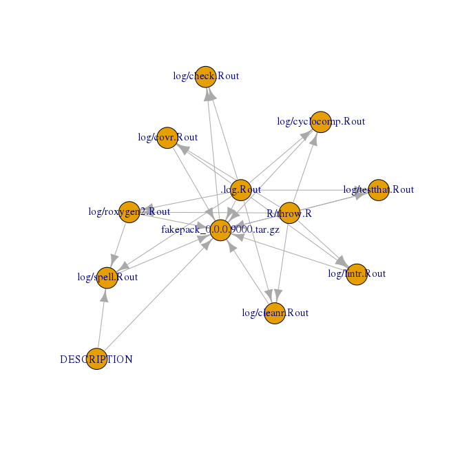

```r
withr::with_dir(pkg_path, fakemake::visualize(ml))
```

Obviously the tarball depends on many files and the only target that’s no other target’s prerequisite is “log/check.Rout”. If you are more into hierarchical depictions, you can use the terminal target as root:

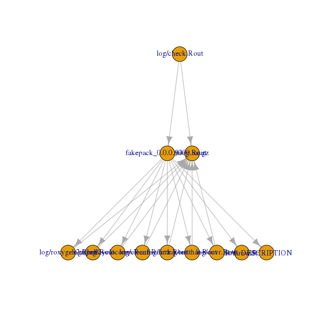

```r
withr::with_dir(pkg_path, fakemake::visualize(ml, root = "log/check.Rout"))
```

But then you might be interested in [this python program](https://github.com/lindenb/makefile2graph), it would leave with this graph:

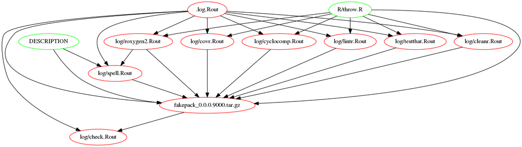

I regularly use it to visualize complex Makefiles.

### More on Target Rules

Let’s take a look at the target rule that builds the tarball:

```r
index <- which(sapply(ml, function(x) x["alias"] == "build"))
ml[[index]]
```

```
## $alias
## [1] "build"
##
## $target
## [1] "get_pkg_archive_path(absolute = FALSE)"
##
## $code
## [1] "print(devtools::build(pkg = \".\", path = \".\"))"
##
## $sink
## [1] "log/build.Rout"
##
## $prerequisites
##  [1] ".log.Rout"
##  [2] "list.files(\"R\", full.names = TRUE, recursive = TRUE)"
##  [3] "list.files(\"man\", full.names = TRUE, recursive = TRUE)"
##  [4] "DESCRIPTION"
##  [5] "file.path(\"log\", \"lintr.Rout\")"
##  [6] "file.path(\"log\", \"cleanr.Rout\")"
##  [7] "file.path(\"log\", \"spell.Rout\")"
##  [8] "file.path(\"log\", \"cyclocomp.Rout\")"
##  [9] "file.path(\"log\", \"covr.Rout\")"
## [10] "file.path(\"log\", \"testthat.Rout\")"
## [11] "file.path(\"log\", \"roxygen2.Rout\")"
```

Note that some of its items are strings giving file names, some are strings that parse as R expressions, and `prerequisites` is a mix of both. Obiously, *fakemake* parses and evaluates these character strings dynamically.

Let us take a look at the prerequisites for `testthat`:

```r
index <- which(sapply(ml, function(x) x["alias"] == "testthat"))
ml[[index]][["prerequisites"]]
```

```
## [1] ".log.Rout"
## [2] "list.files(\"R\", full.names = TRUE, recursive = TRUE)"
## [3] "list.files(\"tests\", full.names = TRUE, recursive = TRUE)"
## [4] "list.files(\"inst\", full.names = TRUE, recursive = TRUE)"
```

## Building the Package

Now we build and check the package in one go:

```r
withr::with_dir(pkg_path, print(fakemake::make("check", ml)))
```

```
##  [1] ".log.Rout"                  "log/cleanr.Rout"
##  [3] "log/covr.Rout"              "log/cyclocomp.Rout"
##  [5] "log/lintr.Rout"             "log/roxygen2.Rout"
##  [7] "log/spell.Rout"             "log/testthat.Rout"
##  [9] "fakepack_0.0.0.9000.tar.gz" "log/check.Rout"
```

We see the files created in the log directory correspond to the names given by *make*:

```r
list.files(file.path(pkg_path, "log"))
```

```
## [1] "build.Rout"     "check.Rout"     "cleanr.Rout"    "covr.Rout"
## [5] "cyclocomp.Rout" "lintr.Rout"     "roxygen2.Rout"  "spell.Rout"
## [9] "testthat.Rout"
```

and we can take a look at one:

```r
cat(readLines(file.path(pkg_path, "log", "roxygen2.Rout")), sep = "\n")
```

```
## Updating roxygen version in /tmp/RtmpMmOcya/fakepack/DESCRIPTION
## Writing NAMESPACE
## Writing throw.Rd
## [1] "/tmp/RtmpMmOcya/fakepack/NAMESPACE"
## [2] "/tmp/RtmpMmOcya/fakepack/man/throw.Rd"
```

Rebuilding the package does not do anything (NULL is returned instead of a the names of targets above), you save quite some CPU time compared to unconditionally reruning the codes in the makelist:

```r
system.time(suppressMessages(withr::with_dir(pkg_path,
                                             print(fakemake::make("check",
                                                                  ml)))))
```

```
##    user  system elapsed
##   0.132   0.000   0.131
```

## Changing Files and Rebulding the Package

Let us take a look at our testing coverage:

```r
cat(readLines(file.path(pkg_path, "log", "covr.Rout")), sep = "\n")
```

[output not shown]

Well, poor. So we add a test file:

```r
dir.create(file.path(pkg_path, "tests", "testthat"), recursive = TRUE)
file.copy(system.file("templates", "testthat.R", package = "fakemake"),
          file.path(pkg_path, "tests"))
```

```
## [1] TRUE
```

```r
file.copy(system.file("templates", "test-throw.R", package = "fakemake"),
          file.path(pkg_path, "tests", "testthat"))
```

```
## [1] TRUE
```

Now we see - besides other things - that `testthat` has two new prerequisites: `tests/testthat.R` and `tests/testthat/test-throw.R`:

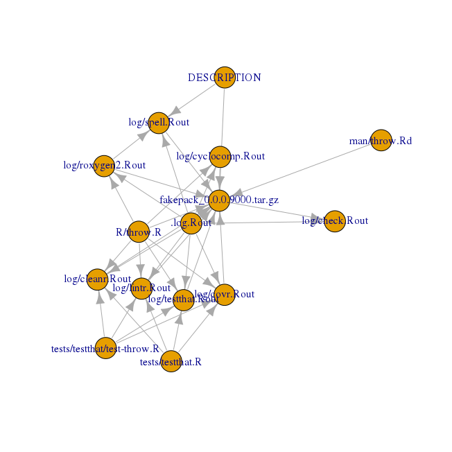

```r
withr::with_dir(pkg_path, fakemake::visualize(ml))
```

Now we re-build the package’s tarball again (of course we could `make("check", ml)` again, but for the sake of (CRAN’s) CPU time, I skip the check):

```r
withr::with_dir(pkg_path, print(fakemake::make("build", ml)))
```

```
## [1] "log/cleanr.Rout"            "log/covr.Rout"
## [3] "log/lintr.Rout"             "log/testthat.Rout"
## [5] "fakepack_0.0.0.9000.tar.gz"
```

```r
cat(readLines(file.path(pkg_path, "log", "covr.Rout")), sep = "\n")
```

[output not shown]

# References

Powers, Shelley, Jerry Peek, Tim O’Reilly, and Mike Loudikes. 2002. *Unix Power Tools*. O’Reilly & Associates.

[^1]: This is a nice example of what restrictive software policies are good for: you end up with a buggy imitation like *fakemake* instead of the well established original. You should not regulate software installations for programmers, unless you take away their interpreters/compilers.